# CS 1675 Final Project: Part 1

Exploratory Data Analysis (EDA)

Anastasia Sosnovskikh

## Load packages

Load the packages used for EDA.

```r
library(tidyverse)
```

```r
library(dplyr)
library(ggplot2)
library(caret)
```

## Load Data

Read in the data.

```r
data_url <- 'https://raw.githubusercontent.com/jyurko/CS_1675_Fall_2020/master/HW/final_project/cs_1675_final_project_data.csv'

df_raw <- readr::read_csv(data_url, col_names = TRUE)
```

Separate the variables associated with Step 1.

```r
df_step1_inputs <- df_raw %>% select(xA, xB, x01:x06, response_1)
```

Separate the variables associated with the Option B classification formulation. The `outcome_2` variable is converted to a factor with a specific ordering of the levels. This ordering is used when modeling in `caret` to make sure everyone predicts the `Fail` class as the “positive” class in the confusion matrix.

```r
df_step2_B_inputs <- df_raw %>% select(xA, xB, response_1, x07:x11, outcome_2) %>%
  mutate(outcome_2 = factor(outcome_2, levels = c('Fail', 'Pass')))
```

Separate the variables associated with the Option A classification formulation. The `outcome_2` variable is again converted to a factor with a specific ordering of the levels.

```r
df_step2_A_inputs <- df_raw %>% select(xA, xB, x01:x11, outcome_2) %>%
  mutate(outcome_2 = factor(outcome_2, levels = c('Fail', 'Pass')))
```

Change data types for the whole data frame to perform EDA.

```r
df <- df_raw %>%
  mutate(xA = as.factor(xA),
         xB = as.factor(xB),
         outcome_2 = factor(outcome_2, levels = c('Fail', 'Pass')))
```

Standardize the data.

```r
get_standardized <- function(df) {
  predict(preProcess(df, method = c('center', 'scale')), df)
}
```

Some helper functions to get the features of a particular type.

```r
get_CATEGORICAL_features_list <- function(df){
  colnames(df)[grepl('factor|logical|character',sapply(df,class))]
}
```

```r
get_CONTINIOUS_features_list <- function(df){
  df %>% select(-get_CATEGORICAL_features_list(df)) %>% colnames()
}
```

## Helper Functions

```r
# helper function
binomial_smooth <- function(...) {
  geom_smooth(method = 'glm', method.args = list(family = 'binomial'), ...)
}
```

## Perform Exploratory Data Analysis

##### Get the summary of the variables.

Get a glimpse of the data.

```r
df %>% glimpse()
```

```
## Rows: 2,013
## Columns: 15
## $ xA         <fct> A1, A1, A1, A1, A1, A1, A1, A1, A1, A1, A1, A1, A1, A1, ...
## $ xB         <fct> B1, B1, B1, B1, B1, B1, B1, B1, B1, B1, B1, B1, B1, B1, ...
## $ x01        <dbl> 116.0243, 116.2233, 120.0090, 116.7899, 118.6890, 114.86...
## $ x02        <dbl> 67.22126, 67.22322, 67.99413, 67.58773, 66.92224, 66.513...
## $ x03        <dbl> 157.6709, 150.4697, 155.5444, 159.4190, 154.8513, 150.64...
## $ x04        <dbl> 106.91331, 103.83730, 105.16593, 107.16210, 104.50367, 9...
## $ x05        <dbl> 99.50679, 97.95972, 102.59383, 91.41536, 107.61530, 80.8...
## $ x06        <dbl> 97.16579, 97.83493, 96.89123, 98.71637, 97.41629, 97.168...
## $ x07        <dbl> 142.0740, 142.9439, 144.9922, 145.0192, 145.8730, 144.91...
## $ x08        <dbl> 77.24619, 76.62125, 78.07184, 78.09906, 77.68426, 76.430...
## $ x09        <dbl> 135.8401, 137.1560, 137.3799, 137.2304, 135.3791, 135.88...
## $ x10        <dbl> 62.29576, 62.29373, 63.88513, 54.03932, 63.33956, 65.590...
## $ x11        <dbl> 106.7585, 106.4500, 106.8000, 106.9970, 106.1210, 107.93...
## $ response_1 <dbl> -0.87151245, 3.24318586, 4.47627039, -0.02065380, 0.0647...
## $ outcome_2  <fct> Pass, Fail, Pass, Pass, Fail, Fail, Pass, Pass, Fail, Pa...
```

Get a summary of the variables.

```r
df %>% summary()
```

```
##   xA        xB           x01             x02             x03
##  A1: 847   B1:463   Min.   :111.9   Min.   :65.44   Min.   :146.2
##  A2:1166   B2:585   1st Qu.:116.5   1st Qu.:66.62   1st Qu.:154.9
##            B3:537   Median :117.7   Median :66.93   Median :156.9
##            B4:428   Mean   :117.7   Mean   :66.94   Mean   :156.9
##                     3rd Qu.:118.8   3rd Qu.:67.27   3rd Qu.:159.0
##                     Max.   :122.8   Max.   :68.45   Max.   :167.0
##       x04              x05              x06             x07
##  Min.   : 95.55   Min.   : 76.12   Min.   :96.62   Min.   :140.3
##  1st Qu.:104.71   1st Qu.: 98.85   1st Qu.:97.46   1st Qu.:143.4
##  Median :106.47   Median :103.32   Median :97.69   Median :144.3
##  Mean   :106.48   Mean   :103.23   Mean   :97.69   Mean   :144.2
##  3rd Qu.:108.41   3rd Qu.:107.65   3rd Qu.:97.94   3rd Qu.:145.0
##  Max.   :114.77   Max.   :125.22   Max.   :98.91   Max.   :148.8
##       x08             x09             x10             x11
##  Min.   :74.04   Min.   :131.0   Min.   :51.21   Min.   :105.3
##  1st Qu.:77.75   1st Qu.:135.9   1st Qu.:59.12   1st Qu.:106.4
##  Median :78.63   Median :136.9   Median :60.79   Median :106.7
##  Mean   :78.66   Mean   :136.9   Mean   :60.79   Mean   :106.7
##  3rd Qu.:79.57   3rd Qu.:137.9   3rd Qu.:62.53   3rd Qu.:107.0
##  Max.   :82.92   Max.   :142.0   Max.   :70.26   Max.   :107.9
##    response_1       outcome_2
##  Min.   :-30.5376   Fail: 985
##  1st Qu.: -1.9160   Pass:1028
##  Median :  0.4441
##  Mean   :  0.5003
##  3rd Qu.:  3.2791
##  Max.   : 29.5693
```

Check for missing data using `visdat` package.

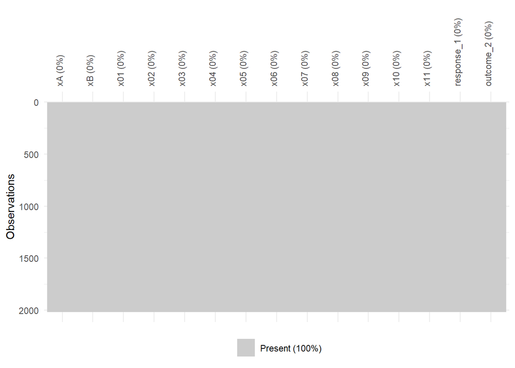

```r
df %>%
  visdat::vis_miss() +
  theme(axis.text.x = element_text(angle = 90))
```

*All the values are present.*

Check for variables with near-zero variance.

```r
df %>% nearZeroVar()
```

```
## integer(0)
```

*There are no variables with a zero variance. Thus, do **not** need to exclude any variables.*

##### Check datatypes.

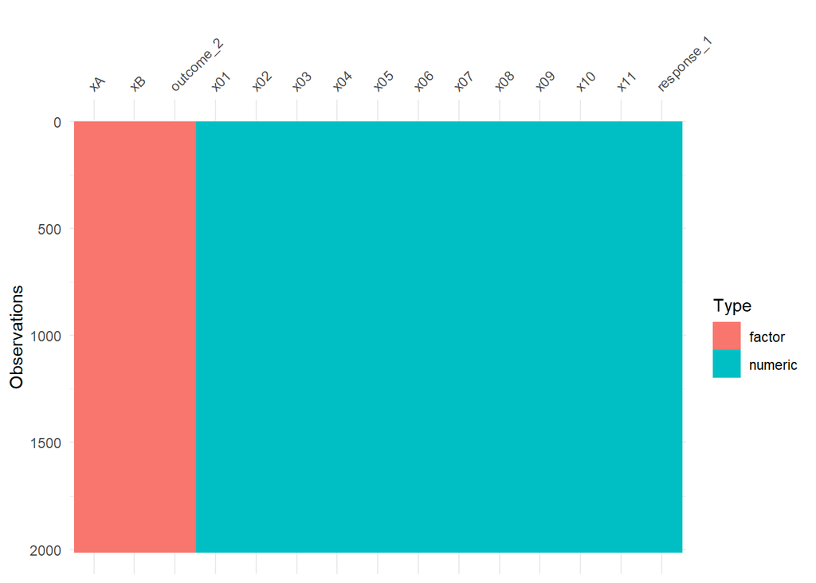

```r
df %>% visdat::vis_dat()
```

```r
categorical_features_list <- df %>% get_CATEGORICAL_features_list()
categorical_features_list
```

```
## [1] "xA"        "xB"        "outcome_2"
```

```r
continous_features_list <- df %>% get_CONTINIOUS_features_list()
continous_features_list
```

```
##  [1] "x01"        "x02"        "x03"        "x04"        "x05"
##  [6] "x06"        "x07"        "x08"        "x09"        "x10"
## [11] "x11"        "response_1"
```

*As we can see, the variables `xA`, `xB`, and `outcome_2` are **discrete/categorical**, and variables `x01:x011` and `response_1` are **continuous**.*

Check the dimensions.

```r
df %>% dim()
```

```
## [1] 2013   15
```

*The input data set has `2013` observations and `15` features.*

Check the fraction of the target observations in the data set.

```r
mean(df$outcome_2 == 'Fail')
```

```
## [1] 0.4893194
```

*Our models have to perform better than this number. Otherwise, it will be just guessing.*

### 1. Visualize the distribution of the variables in the data set

##### Show **histograms** of all **continuous** variables.

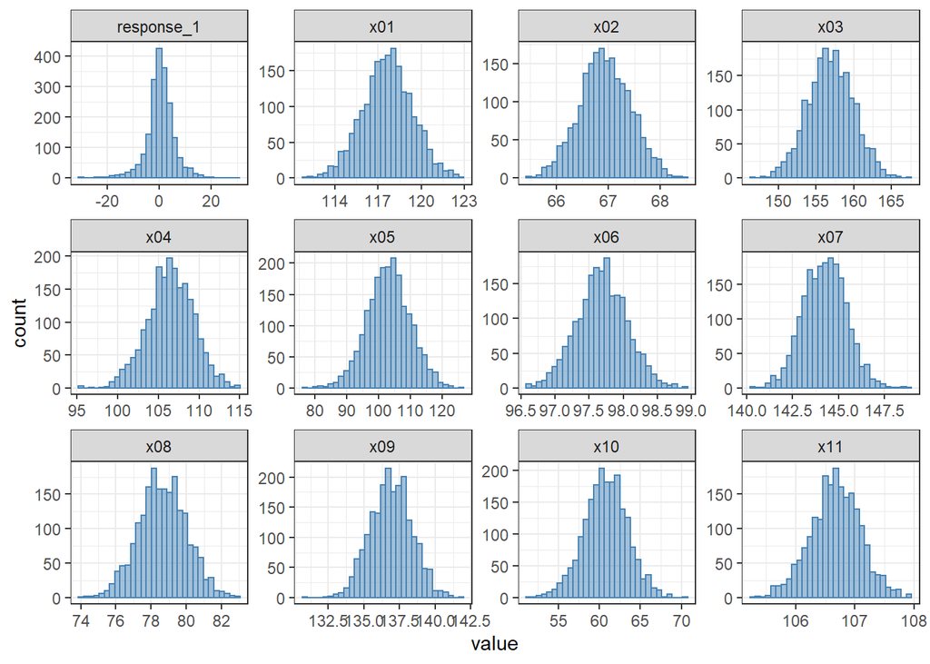

```r
df %>%
  select(all_of(continous_features_list)) %>%
  tibble::rowid_to_column() %>%
  tidyr::gather(key = 'key', value = 'value', -rowid) %>%
  ggplot(mapping = aes(x = value)) +
  geom_histogram(bins = 31,
                 fill = 'steelblue',
                 color = 'steelblue',
                 alpha = 0.5) +
  facet_wrap(~key, scales = 'free') +
  theme_bw()
```

*Continuous variables roughly follow the Gaussian distribution. For `response_1`, the majority of the values are around `0`. The shape is tall and narrow.*

Show densities on top.

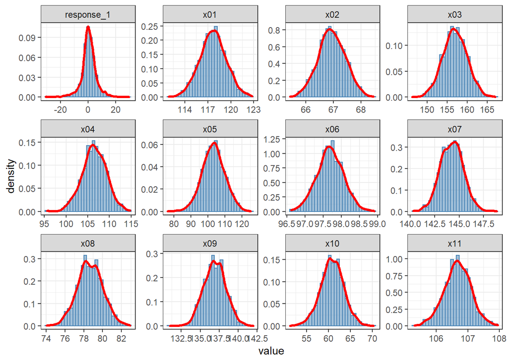

```r
df %>%
  select(all_of(continous_features_list)) %>%
  tibble::rowid_to_column() %>%
  tidyr::gather(key = 'key', value = 'value', -rowid) %>%
  ggplot(mapping = aes(x = value)) +
  geom_histogram(mapping = aes(y = stat(density)),
                 bins = 31,
                 fill = 'steelblue',
                 color = 'steelblue',
                 alpha = 0.5) +
  geom_density(color = 'red',
               size = 1.10) +
  facet_wrap(~key, scales = 'free') +
  theme_bw()
```

```r
# TODO: possibly plot the mean and the median (should be roughly the same for all and match the location of the max)
```

##### Show **boxplots** of all **continuous** variables.

```
## Note: Using an external vector in selections is ambiguous.
## i Use `all_of(continous_features_list)` instead of `continous_features_list` to silence this message.
## i See <https://tidyselect.r-lib.org/reference/faq-external-vector.html>.
```

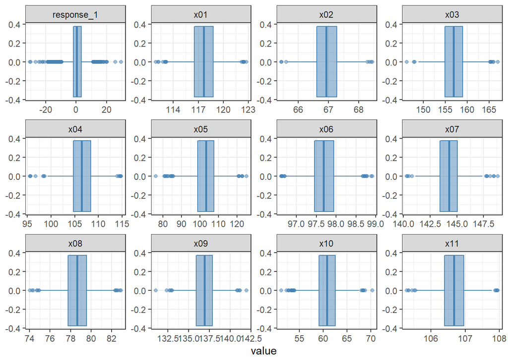

```r
df %>%
  select(continous_features_list) %>%
  tibble::rowid_to_column() %>%
  tidyr::gather(key = 'key', value = 'value', -rowid) %>%
  ggplot(mapping = aes(x = value)) +
  geom_boxplot(mapping = aes(group = key),
               fill = 'steelblue',
               color = 'steelblue',
               alpha = 0.5) +
  facet_wrap(~key, scales = 'free') +
  theme_bw()
```

##### Show **counts** for **discrete/categorical** variables.

Check unique categories for discrete variables.

```r
# TODO: write a function in case you have more variables
df$xA %>% levels()
```

```
## [1] "A1" "A2"
```

```r
df$xB %>% levels()
```

```
## [1] "B1" "B2" "B3" "B4"
```

```r
df$outcome_2 %>% levels()
```

```
## [1] "Fail" "Pass"
```

Check counts.

```r
# TODO: write a function in case you have more variables
df %>% dplyr::count(xA)
```

```
## # A tibble: 2 x 2
##   xA        n
##   <fct> <int>
## 1 A1      847
## 2 A2     1166
```

```r
df %>% dplyr::count(xB)
```

```
## # A tibble: 4 x 2
##   xB        n
##   <fct> <int>
## 1 B1      463
## 2 B2      585
## 3 B3      537
## 4 B4      428
```

```r
df %>% dplyr::count(outcome_2)
```

```
## # A tibble: 2 x 2
##   outcome_2     n
##   <fct>     <int>
## 1 Fail        985
## 2 Pass       1028
```

*We have `985` samples that `Fail`, and `1028` samples that `Pass`.*

##### Show **Bar Graph** of all **Discrete** variables.

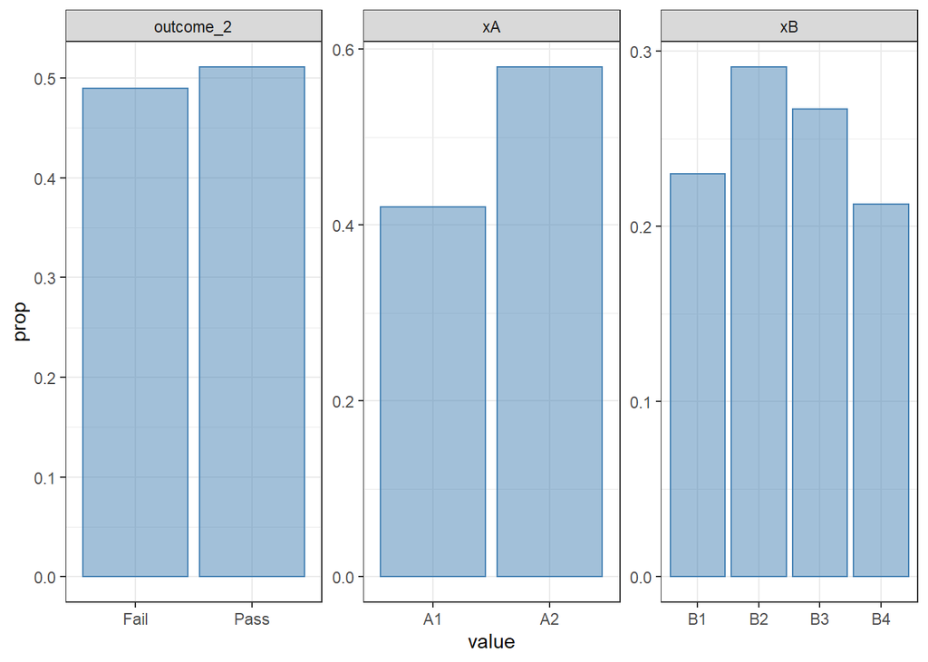

```r
df %>%
  select(all_of(categorical_features_list)) %>%
  tibble::rowid_to_column() %>%
  tidyr::gather(key = 'key', value = 'value', -rowid) %>%
  ggplot(mapping = aes(x = value, y = stat(prop), group = 1)) +
  geom_bar(fill = 'steelblue',
           color = 'steelblue',
           alpha = 0.5) +
  facet_wrap(~ key, scales = 'free') +
  theme_bw()
```

*We do **not** have any low frequency counts. Thus, the **resampling** is feasible.*

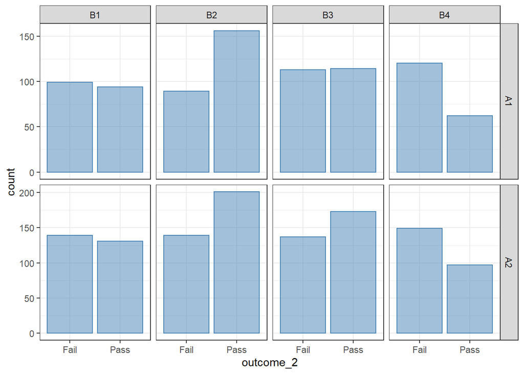

```r
df %>%
  ggplot(mapping = aes(x = outcome_2)) +
  geom_bar(fill = 'steelblue',
           color = 'steelblue',
           alpha = 0.5) +
  facet_grid(xA ~ xB, scales = 'free') +
  theme_bw()
```

*It seems like `xA A1` and `xB B2` input values maximize `Pass`, so minimize `Fail`.*

Show the behavior of outcome_2 with respect to the all the continuous inputs and response_1.

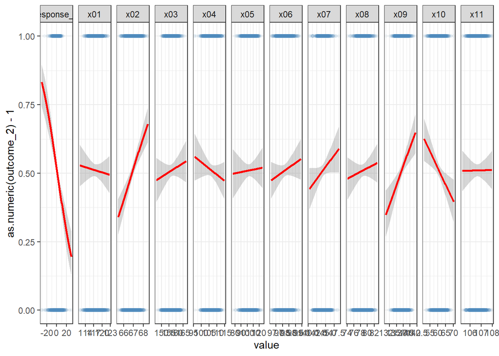

```r
df %>%
  tibble::rowid_to_column() %>%
  tidyr::gather(key = 'key', value = 'value', -rowid, -outcome_2, -xA, -xB) %>%
  ggplot(mapping = aes(x = value, y = as.numeric(outcome_2) - 1)) +
  geom_point(fill = 'steelblue',
             color = 'steelblue',
             alpha = 0.05) +
  binomial_smooth(color = 'red') +
  facet_grid(~ key , scales = 'free') +
  theme_bw()
```

*The variables that have the **most** impact on the `outcome_2` are `x02` and `x09` (positive relationship) as well as `response_1` and `x10` (negative relationship). Other variables have a weaker relationship. `x11` does not seem to impact the `outcome_2` at all.*

### 2. Break up the continuous variables based on the discrete xA and xB variables.

#### Are there differences in input values based on the discrete groups?

Show **boxplots** for **continuous** in relation to `xA`.

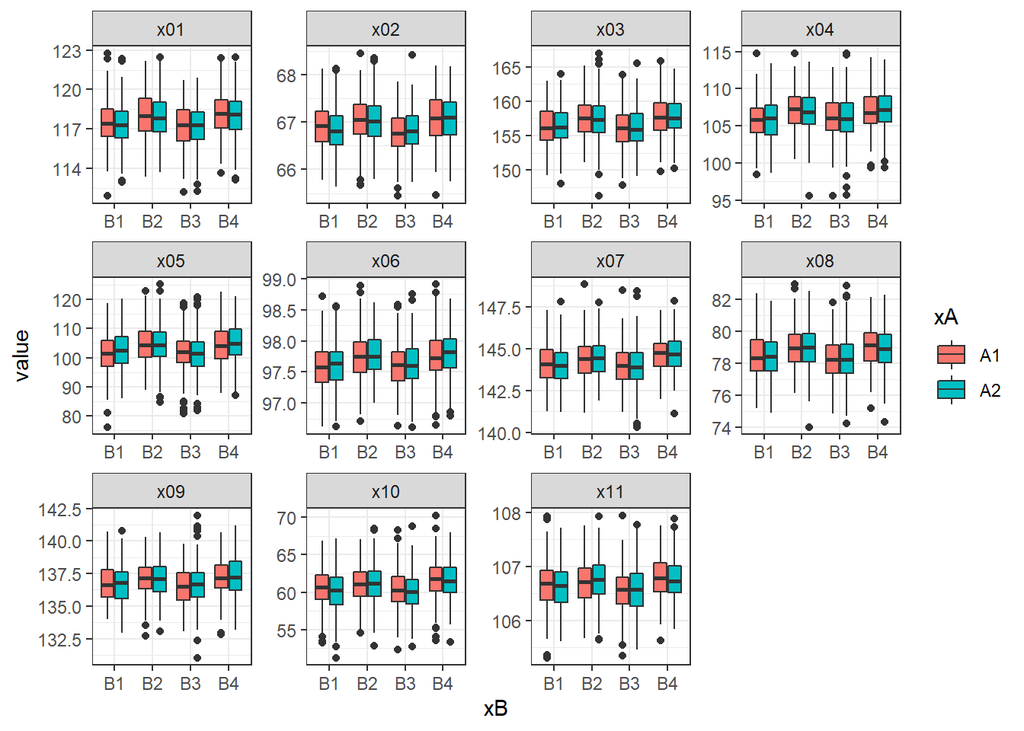

```r
df %>%
  tibble::rowid_to_column() %>%
  tidyr::gather(key = 'key', value = 'value', -rowid,  -response_1, -get_CATEGORICAL_features_list(df)) %>%
  ggplot(mapping = aes(x = xB, y = value)) +
  geom_boxplot(mapping = aes(fill = xA)) +
  facet_wrap(~key, scales = 'free') +
  theme_bw()
```

*`xA` does not seem to impact the variables much because all the boxplots are overlapping and almost exactly the same within the groups.*

Show **boxplots** for **continuous** variables in relation to `xB`.

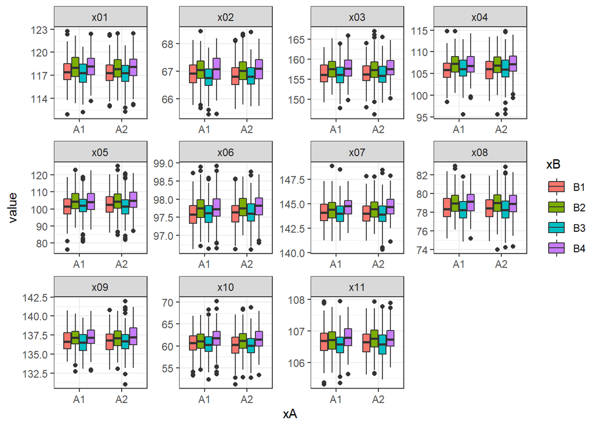

```r
df %>%
  tibble::rowid_to_column() %>%
  tidyr::gather(key = 'key', value = 'value', -rowid, -response_1, -get_CATEGORICAL_features_list(df)) %>%
  ggplot(mapping = aes(x = xA, y = value)) +
  geom_boxplot(mapping = aes(fill = xB)) +
  facet_wrap(~key, scales = 'free') +
  theme_bw()
```

*`xB` seems to impact all the variables to an extent because not all the boxplots completely overlap. The is definitely some variation present based on the different levels of `xB`.*

#### Are there differences in `response_1` based on the discrete groups?

Show **boxplots** for **continuous** variable `response_1` in relation to `xA`.

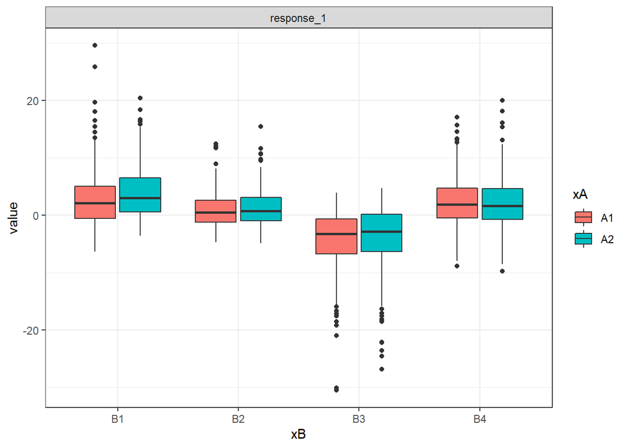

```r
df %>%
  select(c('xA', 'xB', 'response_1')) %>%
  tibble::rowid_to_column() %>%
  tidyr::gather(key = 'key', value = 'value', -rowid, -xA, -xB) %>%
  ggplot(mapping = aes(x = xB, y = value)) +
  geom_boxplot(mapping = aes(fill = xA)) +
  facet_wrap(~key, scales = 'free') +
  theme_bw()
```

*`xA` does not seem to impact `response_1` because all the boxplots overlap.*

Show **boxplots** for **continuous** variable `response_1` in relation to `xB`.

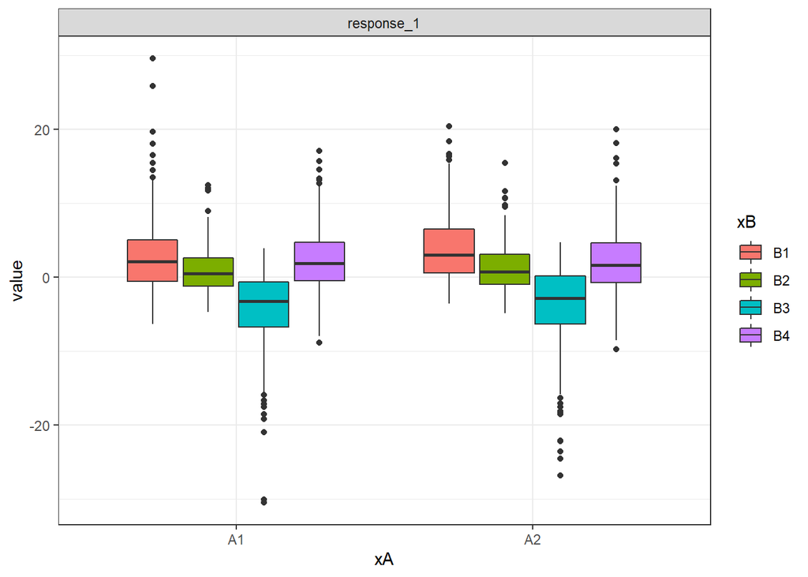

```r
df %>%
  select(c('xA', 'xB', 'response_1')) %>%
  tibble::rowid_to_column() %>%
  tidyr::gather(key = 'key', value = 'value', -rowid, -xA, -xB) %>%
  ggplot(mapping = aes(x = xA, y = value)) +
  geom_boxplot(mapping = aes(fill = xB)) +
  facet_wrap(~key, scales = 'free') +
  theme_bw()
```

*`xB`, however, seems to impact `response_1` because the distribution of `response_1` varies based on the different levels of `xB`.*

### 3.Visualize the relationships between the inputs.

##### Continious variables

Display the correlation between **continuous** inputs using heat map.

```
## Note: Using an external vector in selections is ambiguous.
## i Use `all_of(categorical_features_list)` instead of `categorical_features_list` to silence this message.
## i See <https://tidyselect.r-lib.org/reference/faq-external-vector.html>.
```

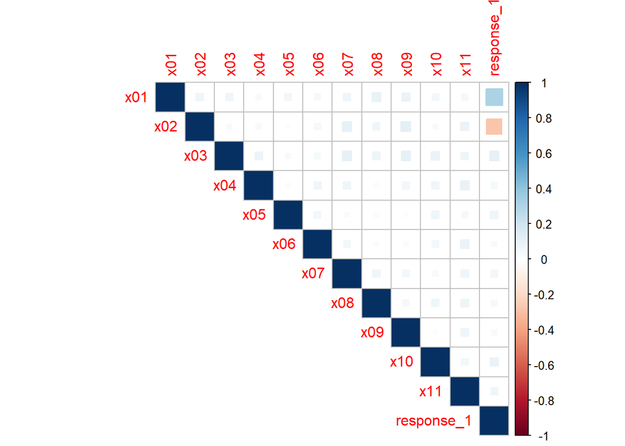

```r
df %>%
  select(-categorical_features_list) %>%
  as.data.frame() %>%
  cor() %>%
  corrplot::corrplot(method = 'square', type = 'upper')
```

Display the correlation between **continuous** inputs with the actual correlation values.

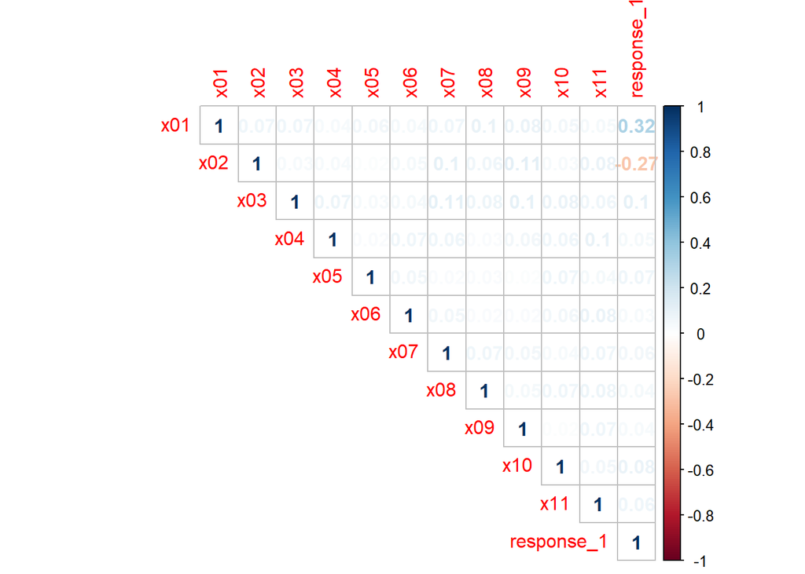

```r
df %>%
  select(-categorical_features_list) %>%
  as.data.frame() %>%
  cor() %>%
  corrplot::corrplot(method = 'number', type = 'upper')
```

Reorder the correlation matrix, using an unsupervised learning technique.

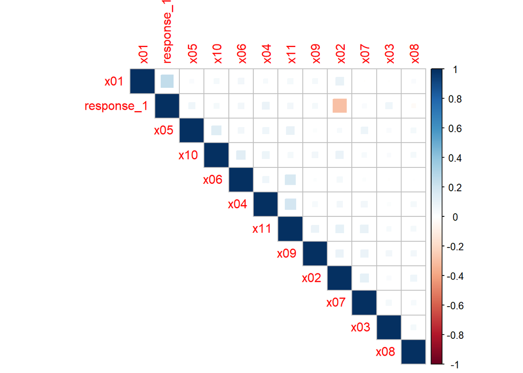

```r
df %>%
  filter(outcome_2 %in% 'Pass') %>%
  select(-categorical_features_list) %>%
  as.data.frame() %>%
  cor() %>%
  corrplot::corrplot(method = 'square', type = 'upper', order = 'hclust')
```

Show the correlation matrix just for the `outcome_2` = `Pass` observations.

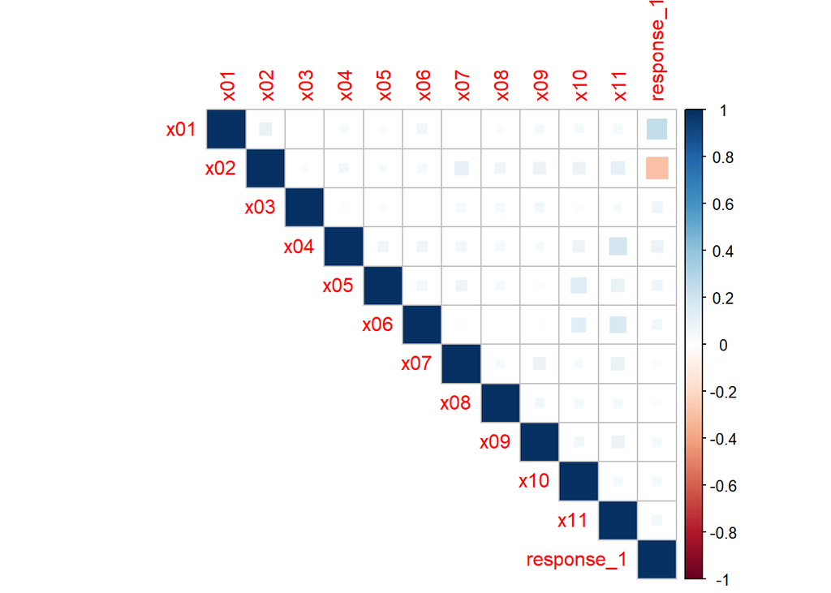

```r
df %>%
  filter(outcome_2 %in% 'Pass') %>%
  select(-categorical_features_list) %>%
  as.data.frame() %>%
  cor() %>%
  corrplot::corrplot(method = 'square', type = 'upper')
```

Show the correlation matrix just for the `outcome_2` = `Fail` observations.

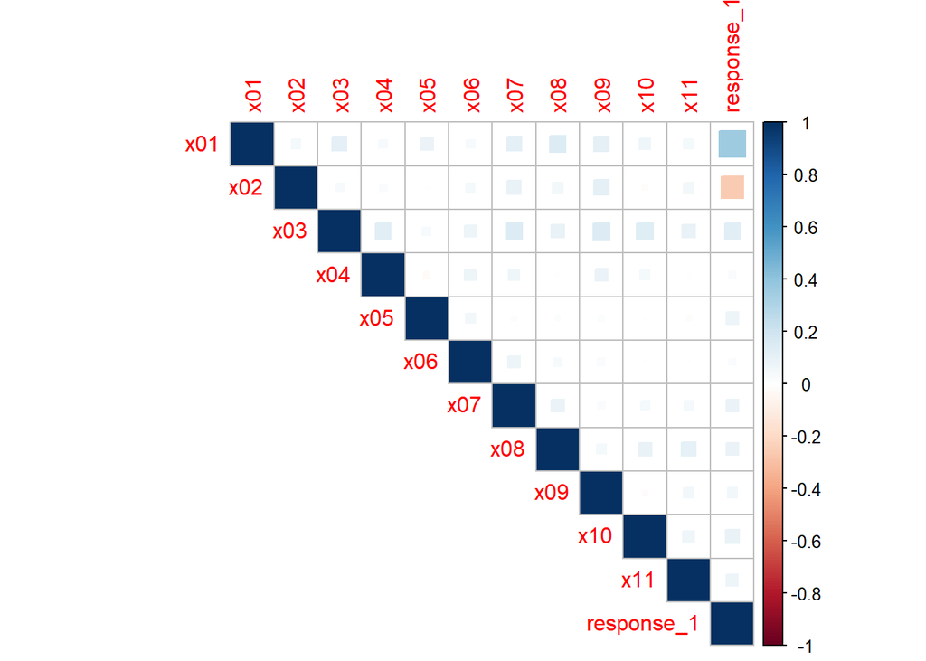

```r
df %>%
  filter(outcome_2 %in% 'Fail') %>%
  select(-categorical_features_list) %>%
  as.data.frame() %>%
  cor() %>%
  corrplot::corrplot(method = 'square', type = 'upper')
```

*The continuous inputs are **not** correlated. Thus, we might need to focus on the models that perform best with uncorrelated inputs.*

##### Discrete / categorical variables

Display the relationship between **discrete/categorical** inputs.

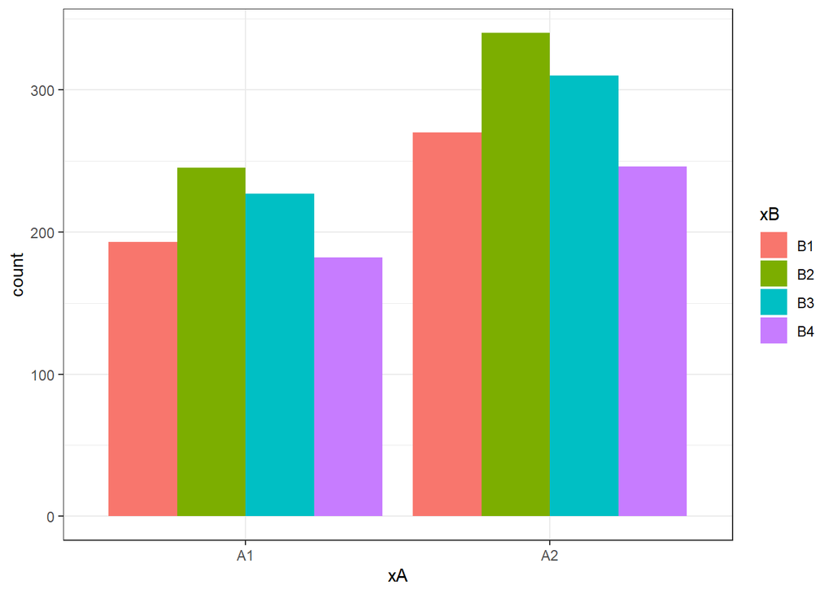

```r
df %>%
  ggplot(mapping = aes(x = xA, fill = xB)) +
  geom_bar(position = 'dodge') +
  theme_bw()
```

### 4. Visualize the relationships between `response_1` and the **Step 1** inputs.

Show the correlation between `response_1` and the **Step 1** **continuous** inputs.

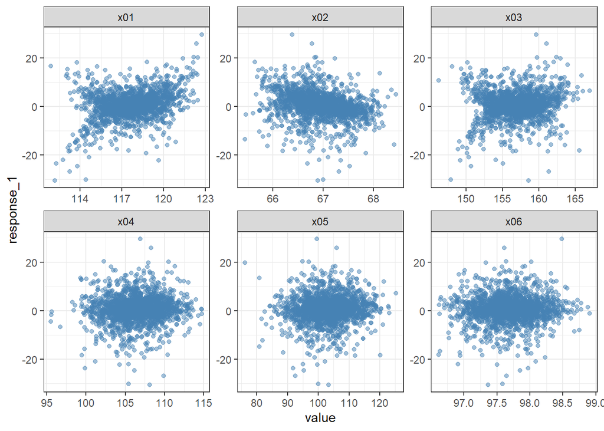

```r
df_step1_inputs %>%
  select(get_CONTINIOUS_features_list(df_step1_inputs)) %>%
  tibble::rowid_to_column() %>%
  tidyr::gather(key = 'key', value = 'value', -rowid, -response_1) %>%
  ggplot(mapping = aes(x = value, y = response_1)) +
  geom_point(fill = 'steelblue',
             color = 'steelblue',
             alpha = 0.5) +
  facet_wrap(~key, scales = 'free') +
  theme_bw()
```

*`response_1` and `x01:x03` seem to be slightly correlated but it is hard to tell using this graph.*

Show the correlation between `response_1` and the **Step 1** **continuous** input with the line.

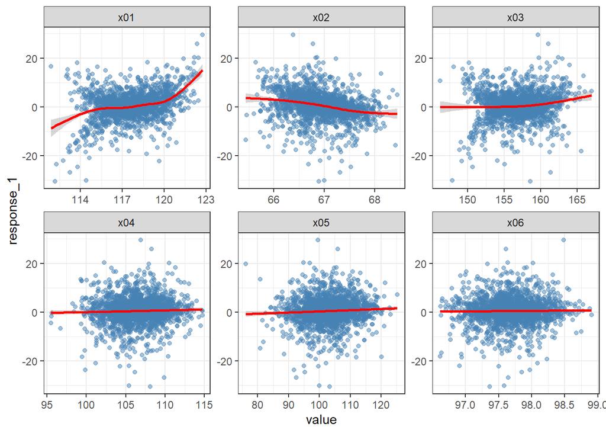

```r
df_step1_inputs %>%
  select(get_CONTINIOUS_features_list(df_step1_inputs)) %>%
  tibble::rowid_to_column() %>%
  tidyr::gather(key = 'key', value = 'value', -rowid, -response_1) %>%
  ggplot(mapping = aes(x = value, y = response_1)) +
  geom_point(fill = 'steelblue',
             color = 'steelblue',
             alpha = 0.5) +
  geom_smooth(color = 'red') +
  facet_wrap(~key, scales = 'free') +
  theme_bw()
```

*Now we can see better that there is a correlation between `response_1` and `x01:x03` inputs.*

Color by categorical variable `xA` .

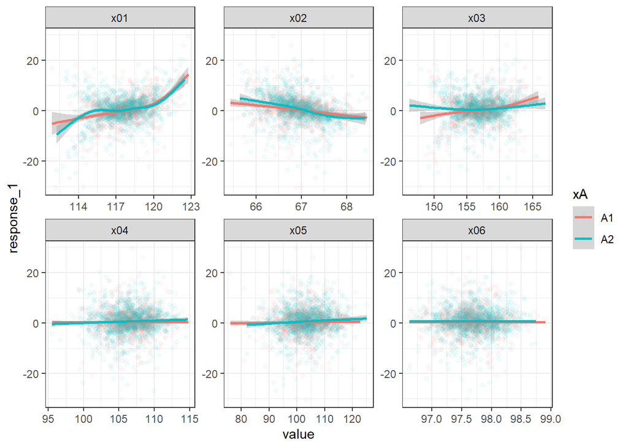

```r
df_step1_inputs %>%
  tibble::rowid_to_column() %>%
  tidyr::gather(key = 'key', value = 'value', -rowid, -response_1, -xA, -xB) %>%
  ggplot(mapping = aes(x = value, y = response_1)) +
  geom_point(mapping = aes(color = xA),
             alpha = 0.05) +
  geom_smooth(mapping = aes(color = xA)) +
  facet_wrap(~key, scales = 'free') +
  theme_bw()
```

*`xA` input does not seem to impact `response_1` as much because `response_1` variable has similar behavior regardless of the levels of `xA`.*

Color by categorical variable `xB` .

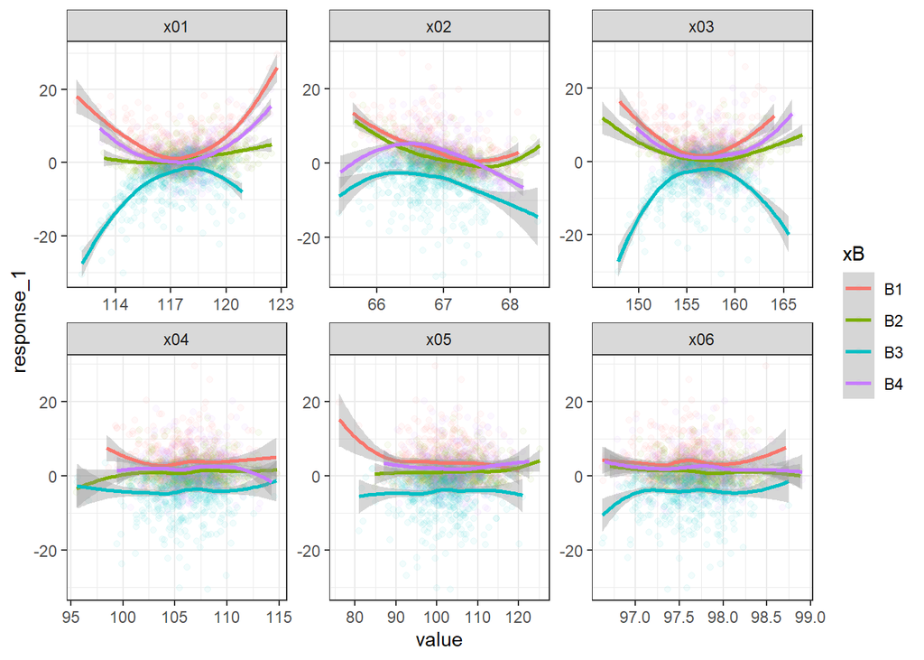

```r
df_step1_inputs %>%
  tibble::rowid_to_column() %>%
  tidyr::gather(key = 'key', value = 'value', -rowid, -response_1, -xA, -xB) %>%
  ggplot(mapping = aes(x = value, y = response_1)) +
  geom_point(mapping = aes(color = xB),
             alpha = 0.05) +
  geom_smooth(mapping = aes(color = xB)) +
  facet_wrap(~key, scales = 'free') +
  theme_bw()
```

*`xB` does impact `response_1` as we can see on the graph.  
Here we have an **interaction** between `response_1` and `xB` for `x01:x03` inputs.

For `x01`, the relationship is mediated by `B3` and seems to be downward parabolic whereas `B1` and `B4` have upward parabolic relationship. The same holds for `x03`. For `x02`, however, `B4` changes the sign and has a downward parabolic behavior.*

### 5. Visualize the behavior of `outcome_2` with respect to the **Step 2** inputs and `response_1`

Show the behavior of `outcome_2` with respect to the **Step 2** **continuous** inputs and `response_1`.

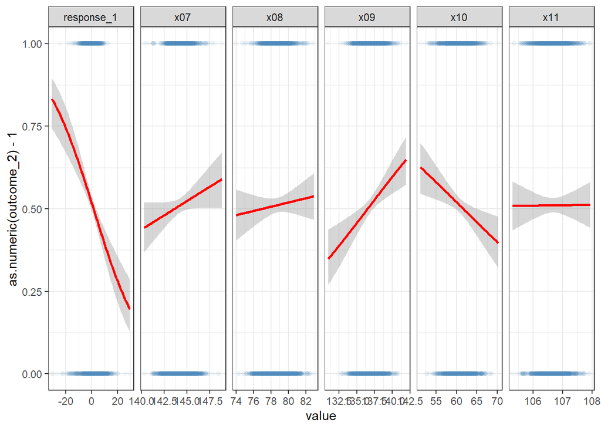

```r
df_step2_B_inputs %>%
  tibble::rowid_to_column() %>%
  tidyr::gather(key = 'key', value = 'value', -rowid, -outcome_2, -xA, -xB) %>%
  ggplot(mapping = aes(x = value, y = as.numeric(outcome_2) - 1)) +
  geom_point(fill = 'steelblue',
             color = 'steelblue',
             alpha = 0.05) +
  binomial_smooth(color = 'red') +
  facet_grid(~ key , scales = 'free') +
  theme_bw()
```

*From the graph, we can see that `outcome_2` and `response_1` are negatively correlated as well as the relationship between the `outcome_2` and `x10`.*

*We have a positive relationship between `outcome_2` and `x07:x09`.*

*There is no relationship between the `outcome_2` and `x11`.*

Color by categorical variable `xA` .

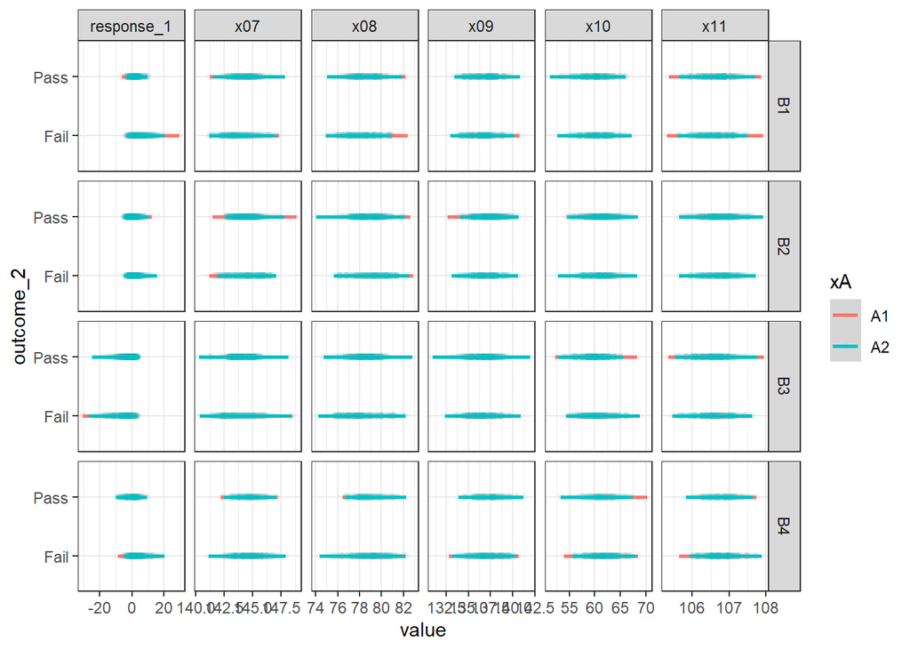

```r
df_step2_B_inputs %>%
  tibble::rowid_to_column() %>%
  tidyr::gather(key = 'key', value = 'value', -rowid, -outcome_2, -xA, -xB) %>%
  ggplot(mapping = aes(x = value, y = outcome_2)) +
  geom_point(mapping = aes(color = xA),
             alpha = 0.05) +
  geom_smooth(mapping = aes(color = xA)) +
  facet_grid(xB ~ key , scales = 'free') +
  theme_bw()
```

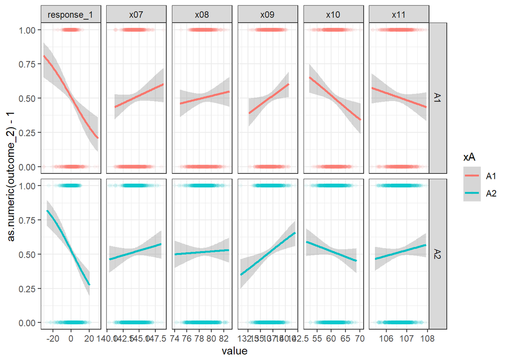

```r
df_step2_B_inputs %>%
  tibble::rowid_to_column() %>%
  tidyr::gather(key = 'key', value = 'value', -rowid, -outcome_2, -xA, -xB) %>%
  ggplot(mapping = aes(x = value, y = as.numeric(outcome_2) - 1)) +
  geom_point(mapping = aes(color = xA),
             alpha = 0.05) +
  binomial_smooth(mapping = aes(color = xA)) +
  facet_grid(xA ~ key , scales = 'free') +
  theme_bw()
```

*`xA` does not seem to cause an interaction between the `outcome_2` and `response_1` as well as `x09` because for both levels the lines are identical. There is a slight interaction for `x07`, `x08`, `x10`. Finally, there is an interaction between the `outcome_2` and `x11` caused by `xA` because the slopes of the lines change based on different levels of `xA`. But if I had to choose, `A1` is more important out of the levels of `xA` because it impacts the `outcome_2` more.*

Color by categorical variable `xB` .

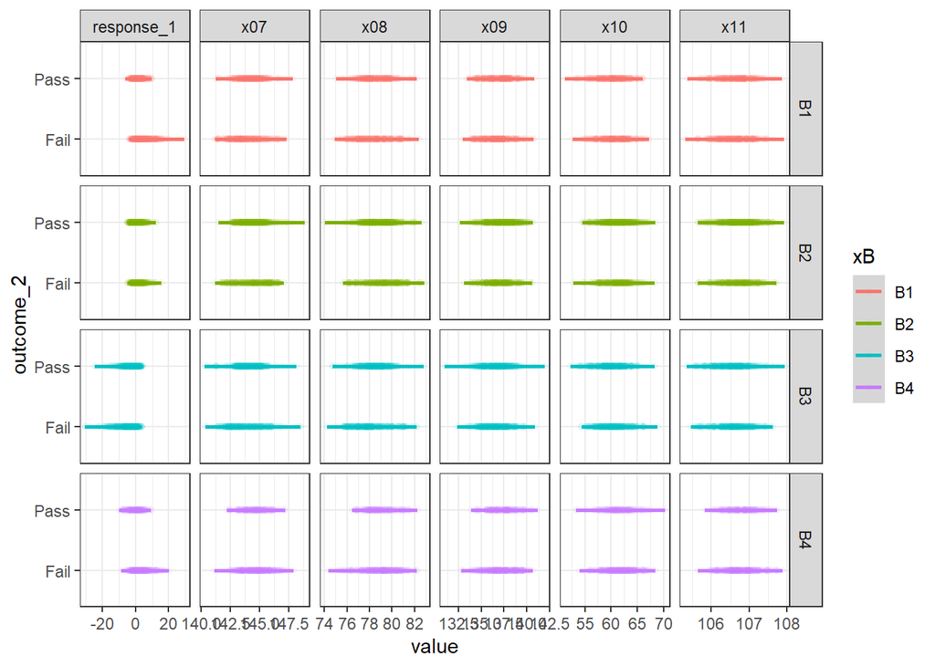

```r
df_step2_B_inputs %>%
  tibble::rowid_to_column() %>%
  tidyr::gather(key = 'key', value = 'value', -rowid, -outcome_2, -xA, -xB) %>%
  ggplot(mapping = aes(x = value, y = outcome_2)) +
  geom_point(mapping = aes(color = xB),
             alpha = 0.05) +
  geom_smooth(mapping = aes(color = xB)) +
  facet_grid(xB ~ key , scales = 'free') +
  theme_bw()
```

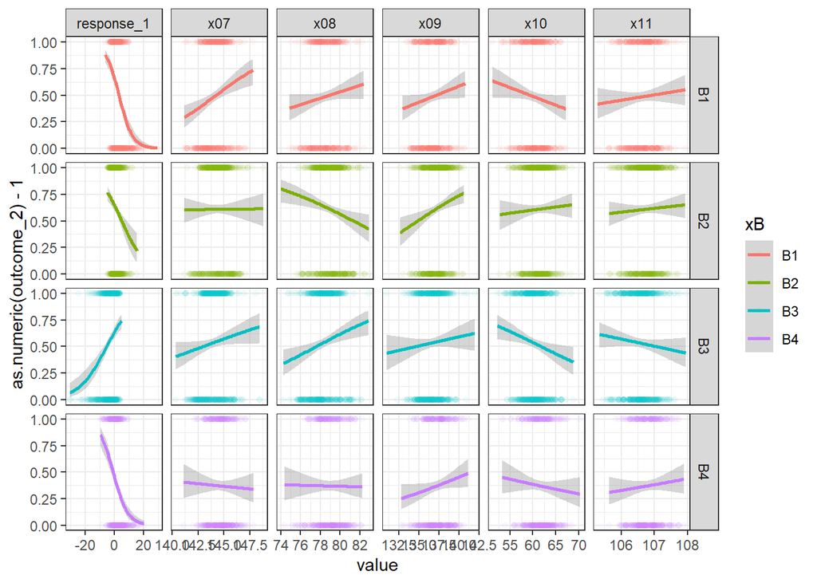

```r
df_step2_B_inputs %>%
  tibble::rowid_to_column() %>%
  tidyr::gather(key = 'key', value = 'value', -rowid, -outcome_2, -xA, -xB) %>%
  ggplot(mapping = aes(x = value, y = as.numeric(outcome_2) - 1)) +
  geom_point(mapping = aes(color = xB),
             alpha = 0.05) +
  binomial_smooth(mapping = aes(color = xB)) +
  facet_grid(xB ~ key , scales = 'free') +
  theme_bw()
```

*There are interactions between the `outcome_2` and the input variables explained by `xB`. The levels of `xB` have the biggest influence on the relationship between `outcome_2` and `response_1.*

Show **boxplots** for input variables in relation to `outcome_2`.

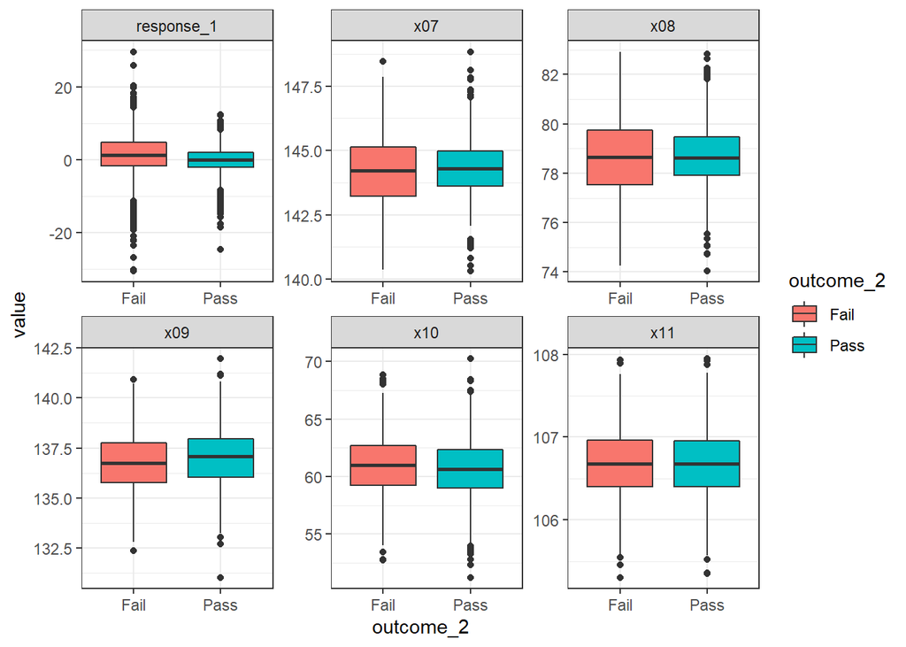

```r
df_step2_B_inputs %>%
  tibble::rowid_to_column() %>%
  tidyr::gather(key = 'key', value = 'value', -rowid, -get_CATEGORICAL_features_list(df)) %>%
  ggplot(mapping = aes(x = outcome_2, y = value)) +
  geom_boxplot(mapping = aes(fill = outcome_2)) +
  facet_wrap(~key, scales = 'free') +
  theme_bw()
```

*It seems like the `outcome_2` does not impact the distribution of a particular continuous input variable; there are, most likely, more complex relationships present.*

Check for multimodal behavior with violin plots.

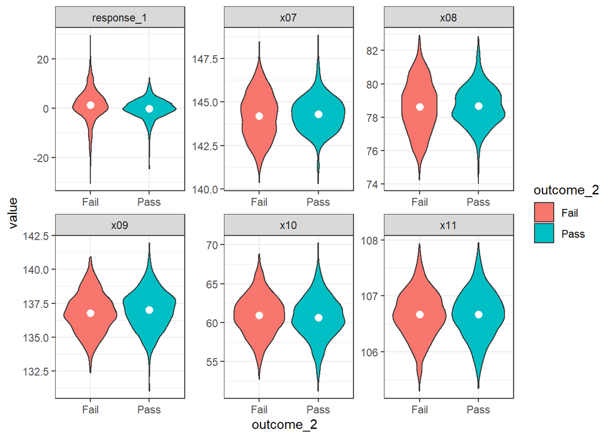

```r
df_step2_B_inputs %>%
  select(c(outcome_2, get_CONTINIOUS_features_list(df_step2_B_inputs))) %>%
  tibble::rowid_to_column() %>%
  tidyr::gather(key = 'key', value = 'value', -rowid, -outcome_2) %>%
  ggplot(mapping = aes(x = outcome_2, y = value)) +
  geom_violin(mapping = aes(group = interaction(key, outcome_2),
                             fill = outcome_2)) +
  stat_summary(fun.data = 'mean_se', color = 'white') +
  facet_grid(outcome_2 ~ .) +
  facet_wrap(~key, scales = 'free') +
  theme_bw()
```

*The variables seem to be roughly unimodal.*

Break up the continuous variables by the binary outcome

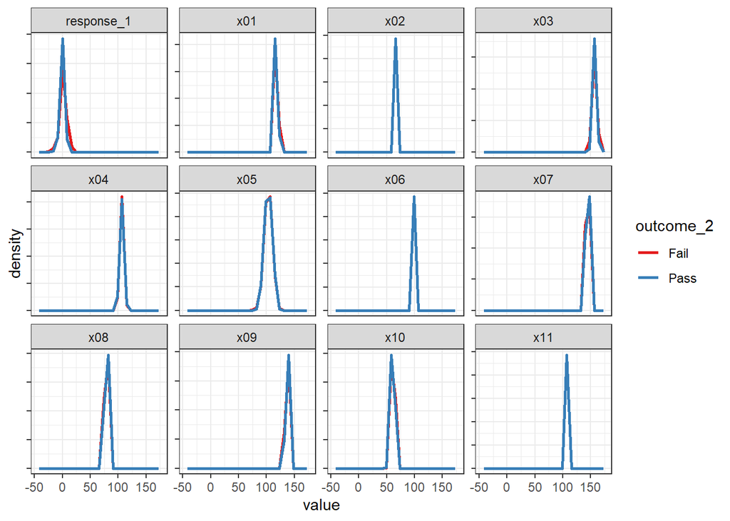

```r
df %>%
  select(c(outcome_2, get_CONTINIOUS_features_list(df))) %>%
  tibble::rowid_to_column() %>%
  tidyr::gather(key = 'key', value = 'value', -rowid, -outcome_2) %>%
  ggplot(mapping = aes(x = value)) +
  geom_freqpoly(bins = 25,
                mapping = aes(color = outcome_2,
                              y = stat(density)),
                size = 1.) +
  facet_wrap(~key, scales = "free_y") +
  scale_color_brewer(palette = "Set1") +
  theme_bw() +
  theme(axis.text.y = element_blank())
```

*The distribution of the results is the same regardless of the class.*